# Quick Intro to Markdown

mph

# Introduction

An R markdown has file extension *.Rmd* and you can create one in RStudio by selecting File -> New File -> R Markdown.

The basic idea here is that an R markdown combines formatable text along with executable code chunks to tell a wonderful story via a nice-looking, sharable document (usually .html or .pdf). In this class, we will generally compile .Rmd files to produce an .html file.

In RStudio, you compile your markdown file by clicking on the knit button (look for the blue ball of yarn!). An .html file will be created, saved in your working folder, and it will also appear in a new viewing window for your inspection. Always read over your output .html file for typos and sizing and general read-ability before submitting your work.

What follows here is a short example of some features of a markdown file. The presentations I’ve shared in class so have also been created via R markdown files.

# Formatting

Here’s a nice link to show you how to do [basic Markdown formatting](https://rmarkdown.rstudio.com/authoring_basics.html). In a markdown file you can easily do the following:

Type **bold type** and *italics*.

> Make a block quote, which can be a nice way to highlight an item of importance or summarize a section.

You can include links: [the story of 8](https://mphitchman.com/eight)

You can create a bullet list of favorite numbers:

- 8
- 4
- $\pi$
- $\frac{1+\sqrt{5}}{2}$

or a numbered list of favorite MLB players:

1. Hank Aaron
2. Edgar Martinez
3. Greg Maddux

## Format Mathematics

You’ll be pleased to know that you can include mathematics typesetting using standard LaTeX in an R Markdown file, either in-line: $x^2 = 8$, or own-line:
$$\bar{x} \pm
2\cdot\frac{s}{\sqrt{n}}.$$

## Headings

In a markdown file we specify sections with a hashtag, subsections with double hashtags, and subsubsections with triple hashtags:

# Code Chunks

We can weave R code into a markdown file. Perhaps we want to share an interesting feature from a data set. So we set up the task for the reader, load the data (and necessary packages) and make our case!

Let’s look at MLB batted ball events (bbe) from August of 2024. Which pitcher gave up the most home runs that month? We load the data:

```r
bbe <- read.csv("https://mphitchman.com/stats/sports/data/batted_ball_aug_24.csv")
```

Next, we summarize the distribution of batted ball events by producing a frequency distribution of the `events` variable:

```r
table(bbe$events) |>
  kbl(col.names=c('Event','Frequency')) |>
  kable_styling(full_width=F)
```

| Event | Frequency |
| --- | --- |
| double | 1363 |
| double_play | 71 |
| field_error | 172 |
| field_out | 12432 |
| fielders_choice | 67 |
| fielders_choice_out | 53 |
| force_out | 599 |
| grounded_into_double_play | 524 |
| home_run | 1015 |
| sac_bunt | 69 |
| sac_fly | 192 |
| sac_fly_double_play | 6 |
| single | 4395 |
| triple | 114 |

In all, there were 1015 home runs hit in August. Which pitcher gave up the most?

```r
bbe |>
  select(player_name,events) |>
  filter(events == 'home_run') |>
  group_by(player_name) |>
  summarize(N = n()) |>
  arrange(desc(N)) |>
  slice(1:10) |>
  kbl() |>
  kable_paper("hover", full_width = F)
```

| player_name | N |
| --- | --- |
| Spiers, Carson | 11 |
| Gray, Sonny | 9 |
| Imanaga, Shota | 9 |
| Irvin, Jake | 9 |
| Kirby, George | 9 |
| Meyer, Max | 9 |
| Bellozo, Valente | 8 |
| Ortiz, Luis L. | 8 |
| Rea, Colin | 8 |
| Castillo, Luis | 7 |

Let’s look at the pitch type and release speed of Carson Spiers batted ball events, along with marking those 11 home runs:

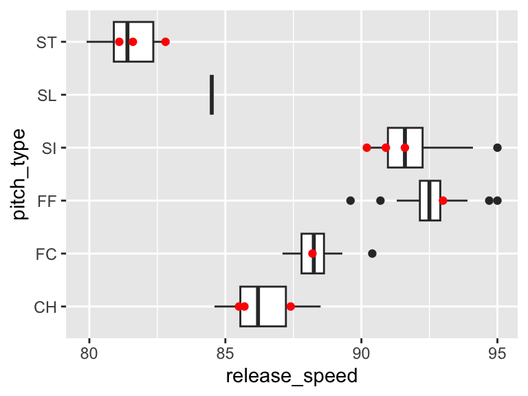

```r
ggplot(bbe |> filter(player_name=='Spiers, Carson'))+
  geom_boxplot(aes(x=release_speed,y=pitch_type))+
  geom_point(data= bbe |> filter(player_name=='Spiers, Carson',events=='home_run'),
             aes(x=release_speed,y=pitch_type),col='red')
```

Here’s another plot. Notice the code chunk is hidden, and the plot is larger than the previous one. Code chunk options are at work here - see the discussion of options below.

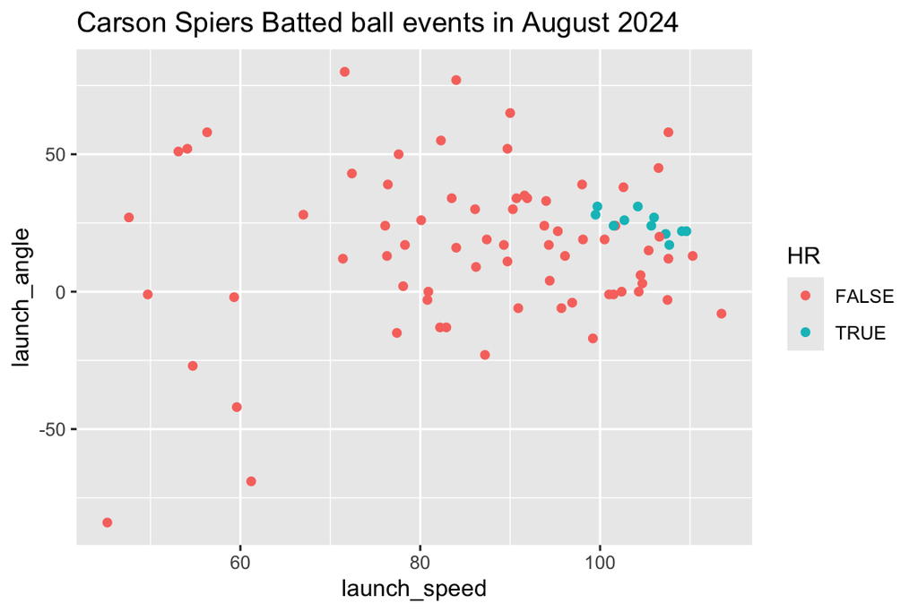

## Code Chunk Options

We can include options in the code chunk header (that initial `{r}`).

- `include = FALSE` hides code and results from appearing in the knitted file. R Markdown still runs the code in the chunk, and the results can be used by other chunks.
- `echo = FALSE` hides code, but not the results from appearing in the knitted file.
- `eval = FALSE` prevents the code chunk from running (though the code will be displayed in the knitted file. Errors will result if later code chunks depend on having evaluated this code chunk.
- `message = FALSE` prevents messages that are generated by code from appearing in the finished file.
- `warning = FALSE` prevents warnings that are generated by code from appearing in the finished.
- `fig.dim = c(5,3)` provides a figure size (in this case 5 wide by 3 high)

In the second figure above, the code chunk header looked like

`{r, echo=FALSE, fig.dim = c(6,4)}`

# in-line code

We can have R execute code and output the result in-line. To report the mean of the vector `v = c(2,3,4,5,6,11)` for instance we can include the following in our markdown file:

The mean of the vector `v` is `` `r round(mean(v),2)`. ``

In the knitted document we would see the line

The mean of the vector `v` is 5.17.